# Wearable technologies and biosignals for user studies [PS0000022]

Practical session #1

[**Luca Menghini, Ph.D.**](https://scholar.google.it/citations?user=ZFRn4ssAAAAJ&hl=it&oi=ao)

***  
Master degree in  
COGNITIVE SCIENCE FOR HUMAN-CENTRIC TECHNOLOGIES  
University of Padova

**TAP THE RIGHT ARROW (→) TO NAVIGATE**

# Practical session 1

## Today

**10:30–10:40** 🧭 Where we are going

**10:40–11:15** ⌚ Wearable technology showcase

**11:15–11:45** 👤👤👤 Group project: case study → research plan

**11:45–11:57** 📢 60–90 second pitches

**11:57–12:00** ✅ Wrap-up

## From online lectures to hands-on work

You have already seen the main building blocks:

→ 👤 User / interaction

→ 💡 Construct

→ ⚡ Biosignal

→ ⌚ Sensor

→ 📈 Features

→ 🔎 Inference

During the practical sessions, we will **build on this chain** while deepening more technical aspects concerning signal pre-processing, data visualization, and data analysis.

## The five practical sessions

5 in-person sessions with practical activities + group project

# Part 1 — Wearable showcase

## What is on the table today?

⌚ **Empatica EmbracePlus**  
PPG · EDA · acceleration · temperature

⌚ **Empatica E4**  
A previous-generation research wearable

❤️ **Polar H10**  
Chest-based cardiac monitoring

💡 **Polar Verity Sense**  
Optical heart-rate monitoring

🏃 **Axivity AX3**  
Raw triaxial accelerometry / actigraphy

👁️ **Mobile eye trackers**  
Gaze behaviour in real-world interaction

Not every device provides real-time access to the raw signal: today the goal is to inspect the devices, try the placement, and understand what kind of data each technology can produce.

## At each station, ask five questions

### 1

### 2

### 3

### 4

### 5

### Where is the sensor placed?

### What does it **directly** measure?

### What variables can be **derived** from it?

### What could contaminate or distort the signal?

### What kind of user study could use it?

### While trying the devices…

Do not ask only **“What can this wearable measure?”**

Ask instead: **“What conclusion about a user could I reasonably support with these measurements?”**

# Part 2 — Group project

## Your challenge

In groups of approximately **3–5 students**, you will design a **wearable-based user study** starting from a case study.

Across the next practical sessions, your project will progressively include:

1. Research question and construct(s)
2. Wearable signal(s) and sensor(s)
3. Study protocol and data acquisition
4. Pre-processing and feature extraction
5. Analysis and visualization plan
6. Interpretation, confounders, and limitations

## From a case study to a research plan

Each group will work on one case study. For your case, start from the same chain:

### 👤 **What is the user doing?**

### 💡 **What construct are you interested in?**

### ⚡ **Which biosignal could reflect a relevant process?**

### ⌚ **Which wearable could measure it in this context?**

### 💥 **What could confound your interpretation?**

## One familiar example

Health chatbot 🤖💬

A user interacts with a chatbot that asks questions about health behaviours and gives personalised feedback.

Some questions are neutral, while others concern more sensitive topics.

You already discussed this scenario in the introductory session.  
**The group project goes one step further:** turn a broad scenario into a *testable user study*.

# Your case studies

## Case 1 — AI study assistant 🤖📚

A university student uses an **AI study assistant** while solving a set of difficult problems.

The assistant sometimes provides **accurate and helpful suggestions**, while in another condition it provides **uncertain or misleading suggestions**.

### How would you study the user’s experience and response to the system?

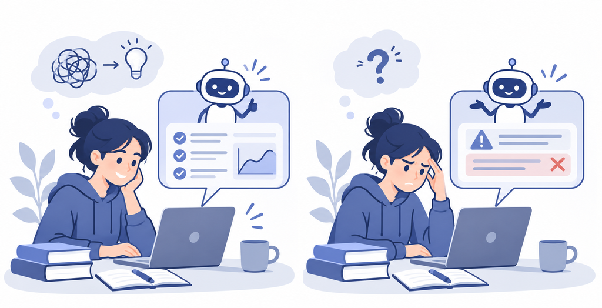

## Case 2 — Notification interruptions 📱🔔

A user performs a **20-minute focused computer task**.

In one condition, smartphone notifications are disabled. In another, the user receives **frequent task-unrelated notifications**.

### How would you study the impact of digital interruptions on the user?

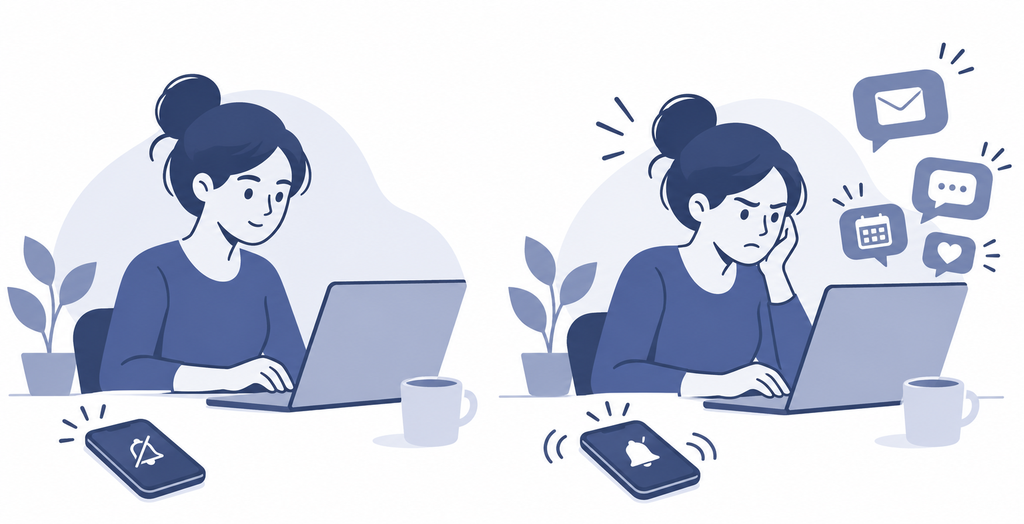

## Case 3 — Adaptive videogame 🎮📈

A player interacts with a videogame whose difficulty adapts automatically.

In one condition, difficulty remains well matched to performance. In another, the game becomes **unexpectedly too easy or too difficult**.

### How would you investigate the player’s response to adaptive difficulty?

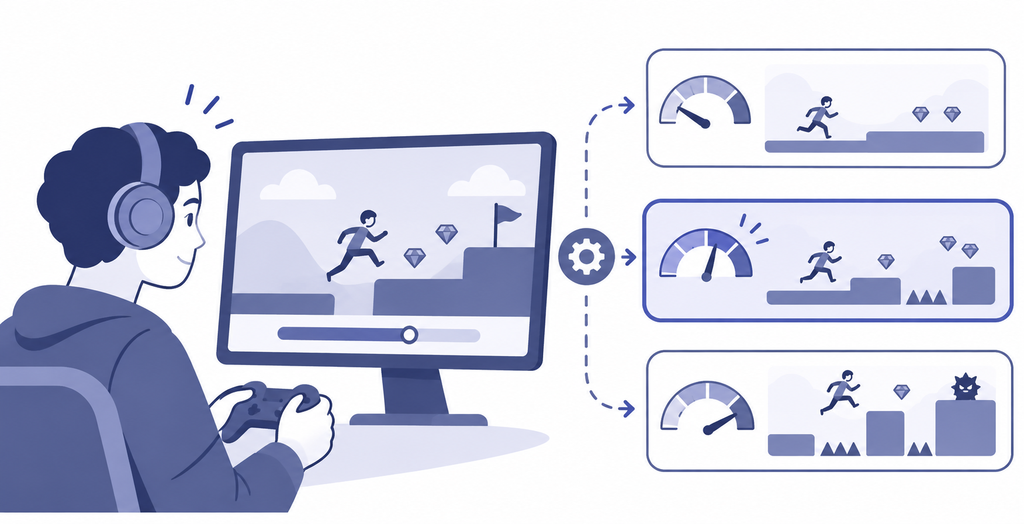

## Case 4 — Digital navigation 🚶📍

A user follows an unfamiliar route while using a mobile navigation system.

The system provides guidance either mainly through **visual instructions on the screen** or through **audio instructions**.

### How would you compare the user experience across the two navigation modes?

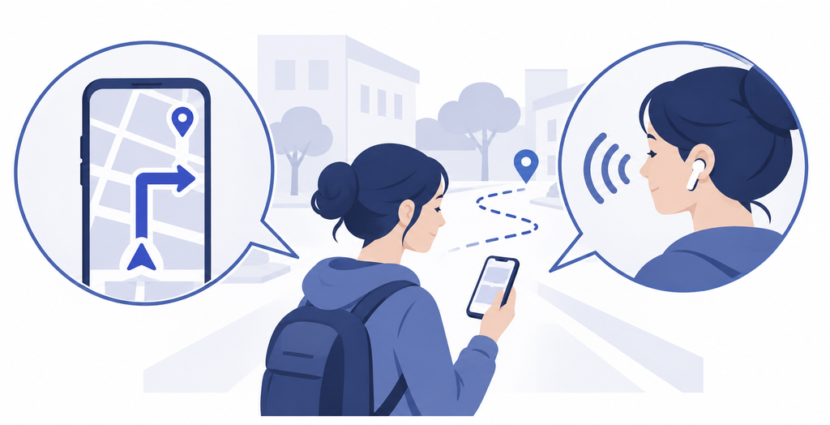

## Case 5 — After-hours work notifications 💻🌙

Employees use a work communication platform across several days.

During some evenings, **work-related notifications remain active after working hours**; during others, notifications are silenced.

### How would you study possible consequences for recovery and sleep?

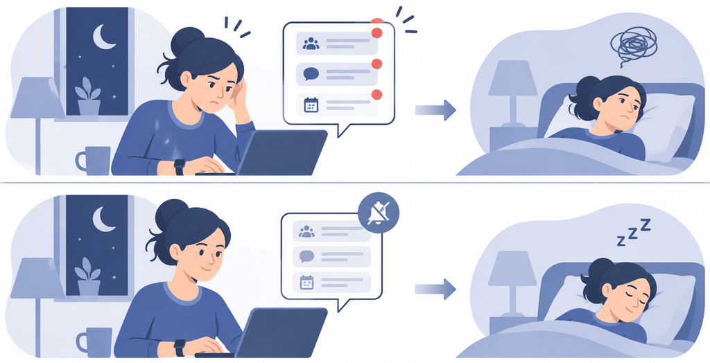

# Today’s group work

## Deliverable: Study idea

By the end of today’s session, agree on:

1. **Research question**  
   What exactly do you want to know?
2. **Target construct(s)**  
   What aspect of the user’s experience or state matters?
3. **Biosignal(s) + wearable sensor(s)**  
   What would you measure, and with what device?
4. **Rationale**  
   Why should those measurements help answer the research question?
5. **Main confounder / alternative explanation**  
   What else could produce the same physiological or behavioural pattern?

## Keep the scope realistic

Your goal is **not** to design the most complicated study possible.

A strong project has a **clear question**, a **defensible measurement strategy**, and an explicit awareness of what the data **cannot** tell you.

Prefer a simple design that you can justify over a complex design full of measurements.

## 60–90 second pitch

One speaker per group. Tell us:

### 1. 👤 What is your user-realted research question?

### 2. 💡 What construct(s) are you interested in?

### 3. ⚡What biosignal(s) will you use?

### 4. ⌚ Which wearable(s) will you use?

### 5. 💥 What are the biggest challenges or confounders?

You do **not** need a complete protocol yet — we will develop that next week.

## Next session — Study design & data recording

Next time we will move from the idea to the **recording protocol**:

- conditions, tasks, and timing
- baseline and recovery periods
- wearable placement and recording
- event timing / synchronization
- movement and other confounders

### We will also collect a common wearable dataset to use in the following R sessions.

## See you next week!

[figure not shown]